# Digitalization in the German county sphere

## Map visualization

Plotting Data with the sf package

Importing Shapefile for Counties

```r
#Importing the shapefile for the counties


kreise <- read_sf('shape/vg2500_krs.shp')

kreise <- kreise %>%
  rename(
    Kennziffer = RS,

    )
```

importing shapefile for Bundesländer

```r
#Importing the shapefile for the counties

laender <- read_sf('shape/vg2500_bld.shp')

laender <- laender %>%
  rename(
    Bundesland = RS)

laender$Bundesland[laender$Bundesland== "03"]<-"NI" #rename shapefiles country codes into understandable abbrevations of the
laender$Bundesland[laender$Bundesland== '05']<-"NRW"
laender$Bundesland[laender$Bundesland== '06']<-"HE"
laender$Bundesland[laender$Bundesland== '07']<-"RLP"
laender$Bundesland[laender$Bundesland== '08']<-"BW"
laender$Bundesland[laender$Bundesland== '09']<-"BY"
laender$Bundesland[laender$Bundesland== '10']<-"SL"
laender$Bundesland[laender$Bundesland== '12']<-"BR"
laender$Bundesland[laender$Bundesland== '13']<-"MV"
laender$Bundesland[laender$Bundesland== '14']<-"SN"
laender$Bundesland[laender$Bundesland== '15']<-"SA"
laender$Bundesland[laender$Bundesland== '16']<-"TH"
laender$Bundesland[laender$Bundesland== '01']<-"SH"
```

Visualizing the strata across the federal states aswell as give some overview of basic variables

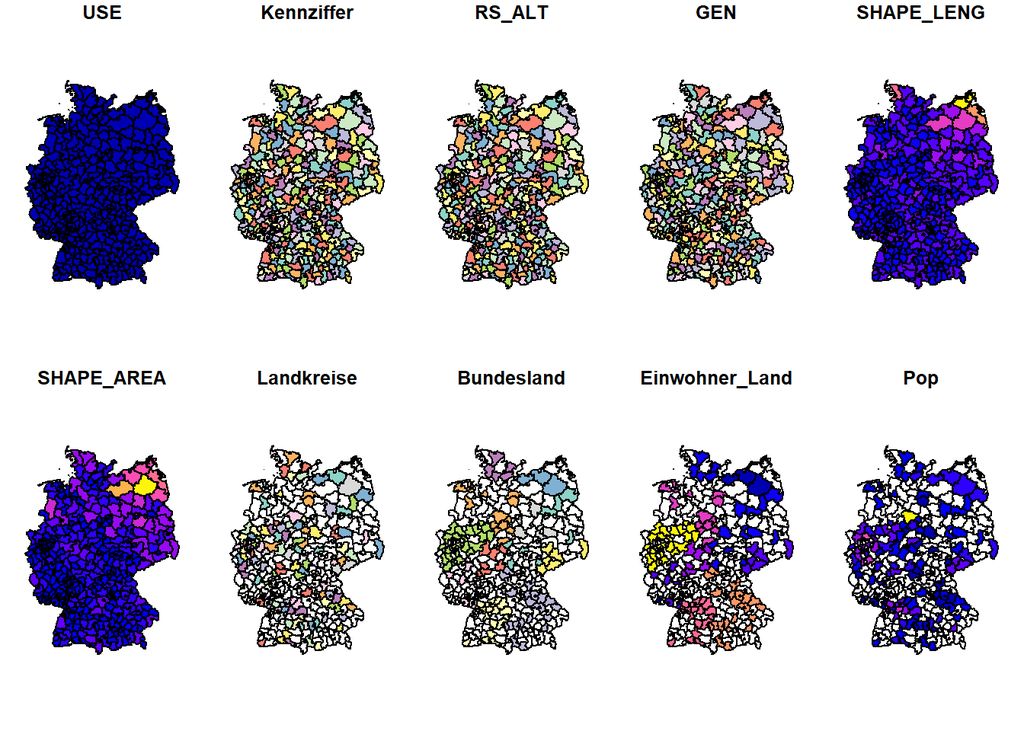

```r
#Importing the shapefile for the counties


kreis_data <-kreise %>% left_join(Index_Dataset_context, by= "Kennziffer")
kreis_data$Partei <-  gsub("P{1}","p", kreis_data$Partei)
plot(kreis_data)
```

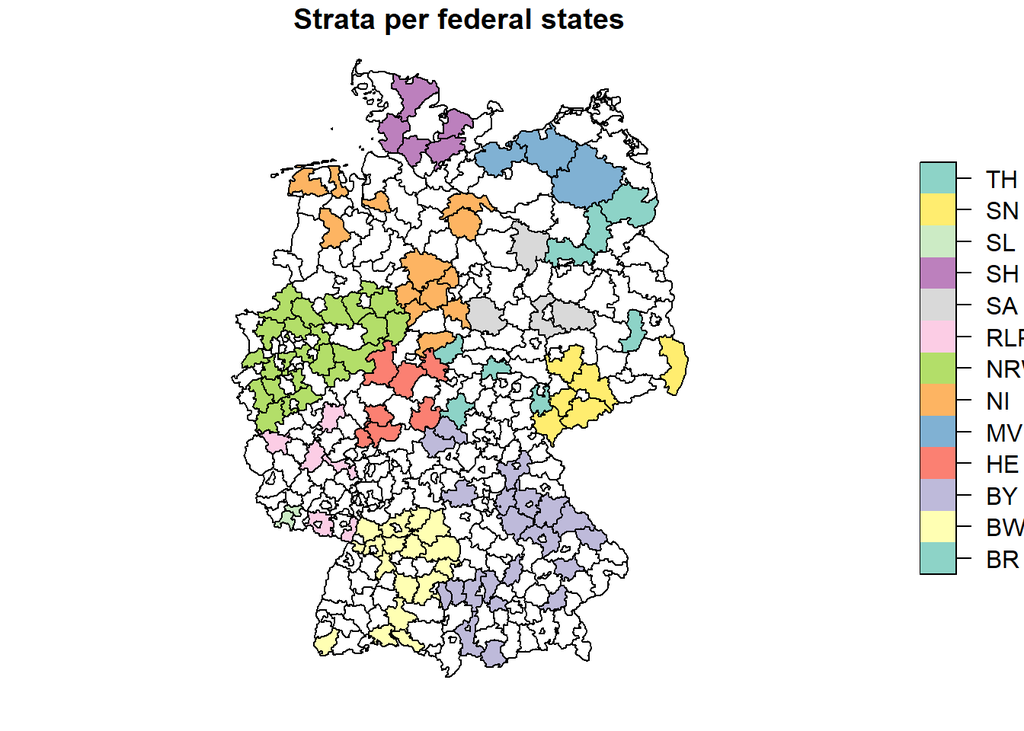

```r
plot(kreis_data["Bundesland"], main = "Strata per federal states")
```

Preparing data for country level and giver simple overview of the different variables

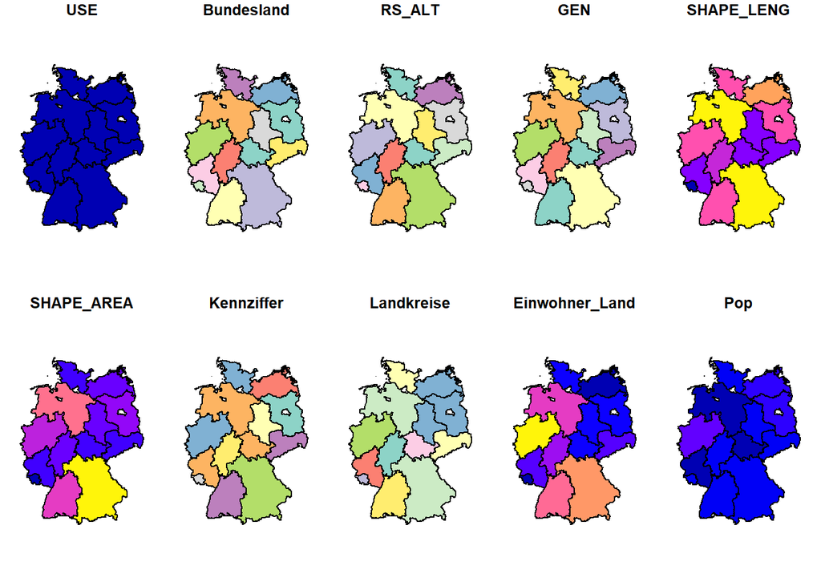

```r
laender_data <-laender %>% left_join(Index_Dataset_context, by= "Bundesland")
laender_data<-subset(laender_data, Bundesland!="02" & Bundesland!="04" & Bundesland !="11")#clean out Bremen, Berlin and Hamburg

plot(laender_data)
```

setting colorscheme of capgemini if necessary for county data

```r
#capgeminis colorcodes


colors = c("#56B1F7" ,"#132B43")
names(colors) = levels(kreis_data$dig_stry)

#special colorcode for parteilos/noparty
colors2 = c("#56B1F7" ,"#132B43")
names(colors2) = levels(factor(kreis_data$Partei == 'parteilos'))
```

Visualizing the digitalization index across German counties

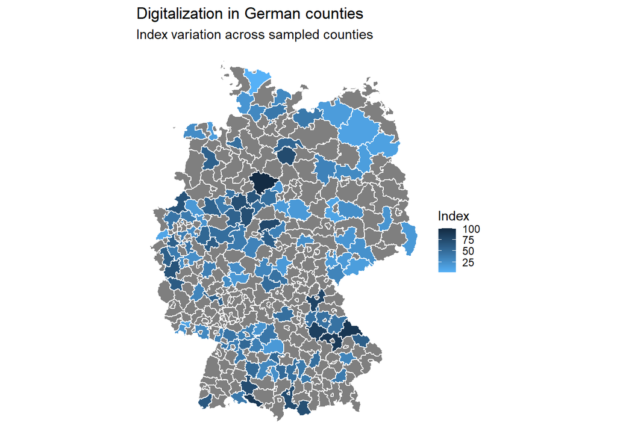

```r
sfmap <-ggplot()+
  geom_sf(data=kreis_data,aes(fill=DigInd_f1_100MAP),color = "white")+
  coord_sf(datum = NA)+
  theme_void()+#show no coordinates
  theme(legend.key.size = unit(1,"line"),
  legend.key.height= unit(0.5,"line"))  +
   scale_fill_continuous(name = "Index", high = "#132B43", low = "#56B1F7")  +
  labs(title="Digitalization in German counties",
       subtitle="Index variation across sampled counties",x="",y="")
sfmap
```

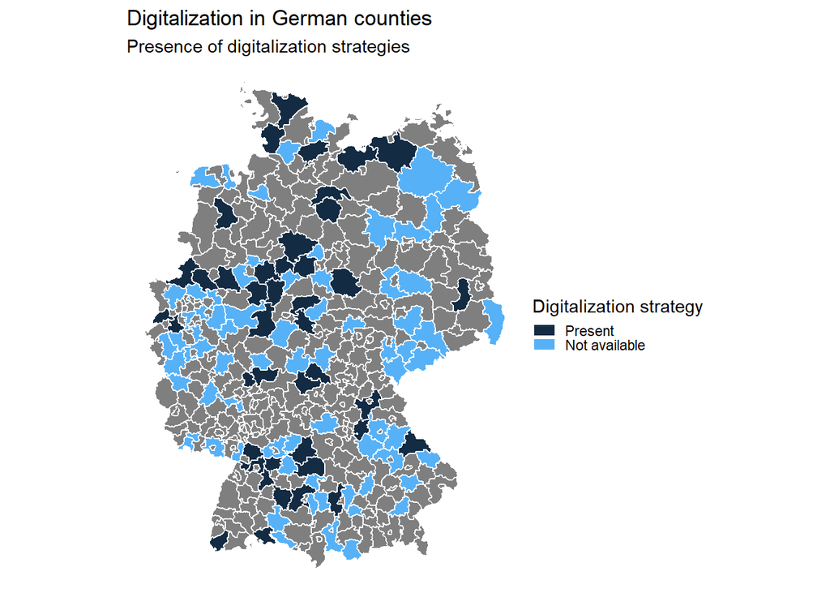

```r
#Importing the shapefile for the counties


colors = c("#56B1F7","#132B43")
names(colors) = levels(kreis_data$dig_stry) # keep colorcode for capgemini since it is not a continous scale anymore

strmap <-ggplot()+
  geom_sf(data=kreis_data,aes(fill=dig_stry),color = "white")+
  coord_sf(datum = NA)+
  theme_void()+ #show no coordinates
  theme(legend.key.size = unit(1,"line"),
  legend.key.height= unit(0.5,"line"))  +
   scale_fill_ordinal(name =  'Presence') +
  labs(title="Digitalization in German counties",
       subtitle="Presence of digitalization strategies ",x="",y="")

strmap + labs(fill = "Digitalization strategy") + guides(fill = guide_legend(reverse=TRUE)) + scale_fill_manual(values = colors,labels = c("Not available", "Present"))
```

Calculating mean of digitalization index by federal state

```r
#Importing the shapefile for the counties


meanlaender <- tapply(laender_data$DigInd_f1_100MAP, laender_data$Bundesland, mean) #calculating Digitalization Index
meanlaender <- as.data.frame(meanlaender)#change fuction into dataframe
meanlaender$Bundesland <- rownames(meanlaender)#give rownames own column


laender_data <-laender_data %>% left_join(meanlaender, by= "Bundesland")#join with länder data
```

visualizing the mean

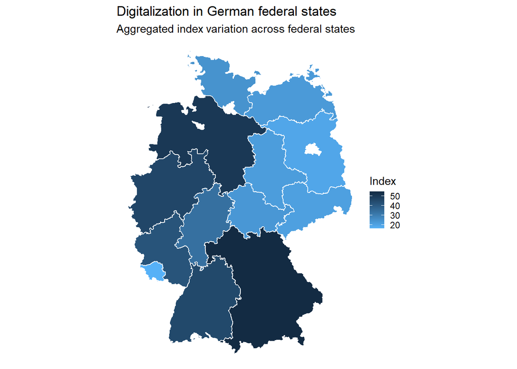

```r
#Importing the shapefile for the counties

sflaender <-ggplot()+
  geom_sf(data=laender_data,aes(fill=laender_data$meanlaender),color = "white")+
  coord_sf(datum = NA)+
  theme_void()+#show no coordinates
  theme(legend.key.size = unit(1,"line"),
  legend.key.height= unit(0.5,"line"))  +
   scale_fill_continuous(name = "Index", high = "#132B43", low = "#56B1F7")  +
  labs(title="Digitalization in German federal states",
       subtitle="Aggregated index variation across federal states",x="",y="")
sflaender
```

visualizing the universities per state

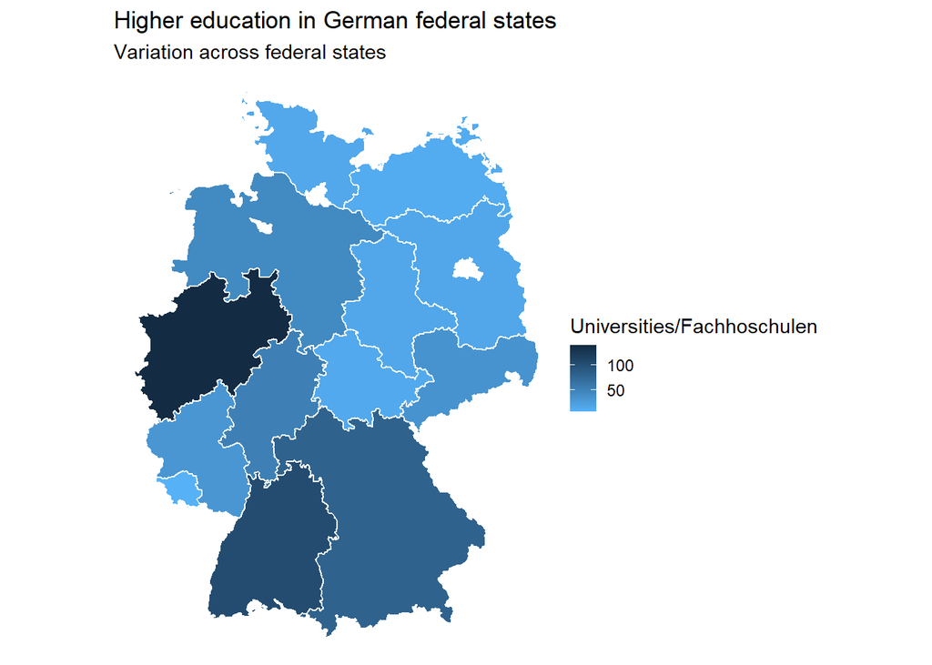

```r
sflaenderUni <-ggplot()+
  geom_sf(data=laender_data,aes(fill=uni_state),color = "white")+
  coord_sf(datum = NA)+
  theme_void()+#show no coordinates
  theme(legend.key.size = unit(1,"line"),
  legend.key.height= unit(0.5,"line"))  +
   scale_fill_continuous(name = "Universities/Fachhoschulen", high = "#132B43", low = "#56B1F7")  +
  labs(title="Higher education in German federal states",
       subtitle="Variation across federal states",x="",y="")
sflaenderUni
```

visualizing the universities per county

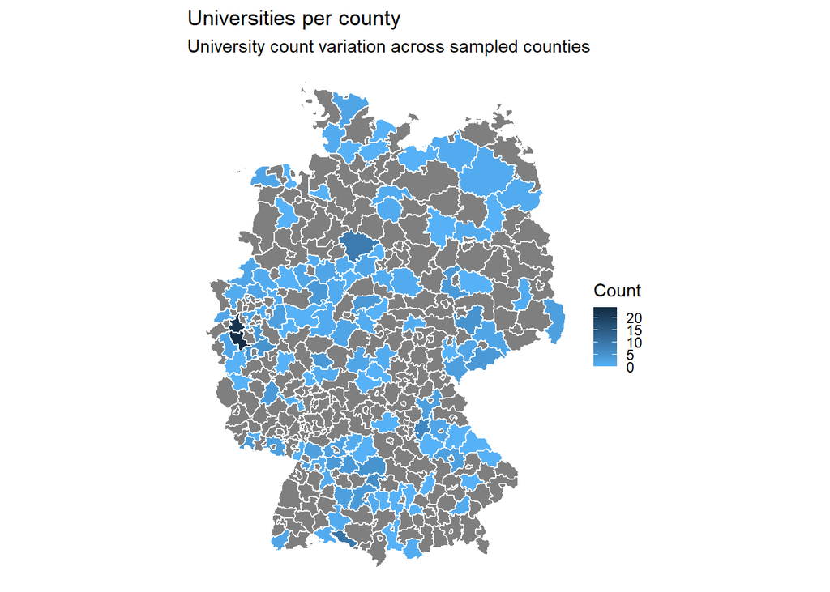

```r
sfunicounty <-ggplot()+
  geom_sf(data=kreis_data,aes(fill=uni_county),color = "white")+
  coord_sf(datum = NA)+
  theme_void()+#show no coordinates
  theme(legend.key.size = unit(1,"line"),
  legend.key.height= unit(0.5,"line"))  +
   scale_fill_continuous(name = "Count", high = "#132B43", low = "#56B1F7")  +
  labs(title="Universities per county",
       subtitle="University count variation across sampled counties",x="",y="")
sfunicounty
```

visualiizing the distribution of independent county administrators

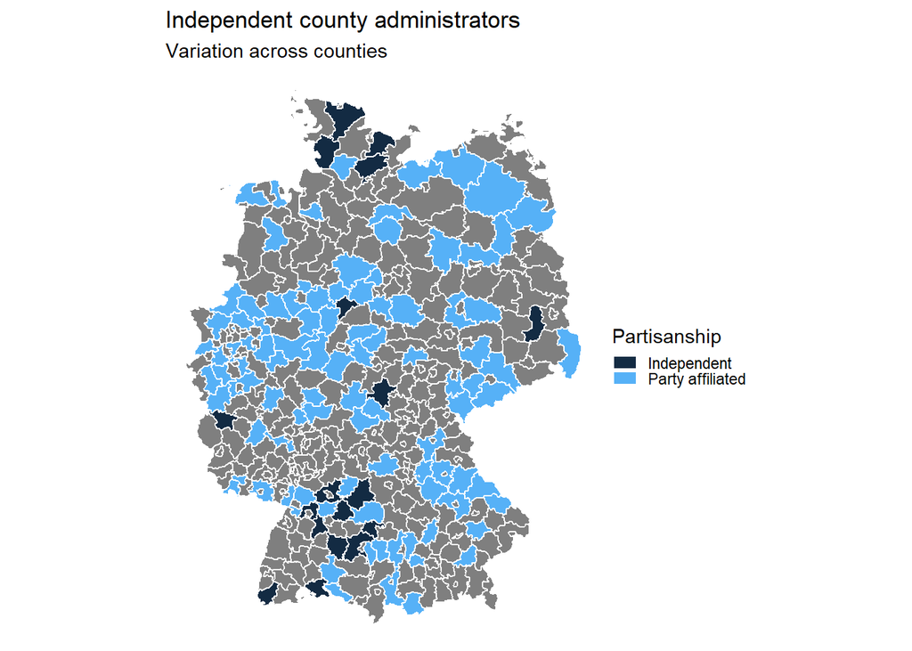

```r
sfmapparteilos <-ggplot()+
  geom_sf(data=kreis_data,aes(fill=factor(Partei == 'parteilos')),color = "white")+
  coord_sf(datum = NA)+
  theme_void()+#show no coordinates
  theme(legend.key.size = unit(1,"line"),
  legend.key.height= unit(0.5,"line")) +
  labs(title="Independent county administrators",
       subtitle="Variation across counties",x="",y="")
sfmapparteilos + labs(fill = "Partisanship") + guides(fill = guide_legend(reverse=TRUE)) + scale_fill_manual(values = colors2,labels = c("Party affiliated", "Independent"))
```